# Introduction

Consumption and saving are perhaps the most important and controversial issues in macroeconomics. In the Solow growth model, saving was a constant fraction $s$ of GDP, by assumption. We now build on *Economics 11* (the one where you learn consumer optimization with Lagrangians and all that), in order to derive saving behavior from microeconomic principles. In other words, we work to make saving “endogenous” (that is, explained by the model), while it was previously taken as exogenous (that is, assumed in the model).

Although this discussion may appear somewhat abstract at first, these calculations are the basis of some of the most important controversies in macroeconomics, which we shall come to in the next lectures.

# The Two-Period Consumption Problem

## Assumptions

There are two periods, $t=0$ (think of this as “today”) and $t=1$ (think of this as “tomorrow”). The consumer values consumption $c_0$ in period $0$ and $c_1$ in period $1$ according to the following utility function:

$$U(c_{0},c_{1})=u(c_{0})+\beta u(c_{1}).$$

where $u(.)$ is an increasing and concave function, and $\beta \leq 1$. $\beta$ captures that people typically have a preference for the present. (they are **present-biased**)

Assume that agents earn (labor) income $y_{0}$ in period $0$, and (labor) income $y_{1}$ in period $1$. They also are born with some financial wealth $f_{0}$ now, and have financial wealth $f_{1}$ in period 1, which they consume entirely because this is the last period. (there is no point keeping more money for after period 1, because there is no future at that point) The amount that agents save in this economy is thus $f_{1}-f_{0}$, and the amount of their accumulated savings is the savings they already had plus what they decided to accumulate, so that $f_{0}+(f_{1}-f_{0})=f_{1}.$

Therefore, consumption in period $0$ is given by:

$$c_{0} =y_{0}-(f_{1}-f_{0})$$

The second period consumption $(t=1)$ is given by income plus the return to (accumulated !) savings:

$$c_{1} =y_{1}+(1+r)f_{1}.$$

## Solution

**Intertemporal budget constraint.** Rewriting $f_{1}$ from this second equation: $f_{1}=(c_{1}-y_{1})/(1+r)$, and plugging into the first,

$$c_{0}=y_{0}-\left(\frac{c_{1}-y_{1}}{1+r}-f_{0}\right).$$
Rearranging, total wealth is then the sum of financial wealth $f_0$ and of the present discounted value of human wealth:

$$c_{0}+\frac{c_{1}}{1+r}=\overbrace{f_{0}+\underbrace{y_{0}+\frac{y_{1}}{1+r}}_{\text{human wealth}}}^{\text{total wealth}}.$$

The intertemporal budget constraint says that the present discounted value of consumption is equal to total wealth.

**Optimization.** The problem of the consumer is then simply that of maximizing utility under his budget constraint:

$$\begin{aligned}
\max_{c_{0},c_{1}} & \quad u(c_{0})+\beta u(c_{1}) \\
& \text{s.t.} \quad c_{0}+\frac{c_{1}}{1+r}=f_{0}+y_{0}+\frac{y_{1}}{1+r}.
\end{aligned}$$

You may solve this optimization in four different ways:

1. Apply the well known ratio of marginal utilities formula from Econ 11. Let us rewrite this optimization problem as follows:
   $$\begin{aligned}
   \max_{c_{0},c_{1}} & \quad u(c_{0})+\beta u(c_{1}) \\
   & \text{s.t.} \quad p_0c_{0}+p_1 c_1=B.
   \end{aligned}$$
   where we have defined the price of consumption in period $0$ by:
   $$p_0 \equiv 1,$$
   the price of consumption in period $1$ by:
   $$p_1 \equiv \frac{1}{1+r},$$
   and finally the budget $B$ by the present discounted value of lifetime resources:
   $$B \equiv f_{0}+y_{0}+\frac{y_{1}}{1+r}.$$
   Note that the relative price of consumption in period $1$ relative to period $0$ is given by $1/(1+r)$: when the interest rate becomes higher, consuming in period $1$ becomes relatively cheaper, or consuming in period $0$ becomes more expensive (it’s really expensive to consume now rather than later if the bank is offering me a really high interest rate). Thus, applying the formula from Econ 11 allows to say that the marginal rate of substitution between consumption in period $1$ $c_1$ and consumption in period $0$ $c_0$ - the ratio of marginal utilities - is equal to the ratio of prices:
   $$\frac{\partial U / \partial c_1}{\partial U / \partial c_0} = \frac{p_1}{p_0}= \frac{1}{1+r} \quad\Rightarrow\quad\frac{\beta u'(c_{1})}{u'(c_{0})}=\frac{1}{1+r}.$$
2. Apply the following intuitive economic argument. The marginal utility from consuming in period $1$ is $\beta u'(c_{1})$. The marginal utility from consuming in period $0$ is $u'(c_{0})$. By putting one unit of consumption in the bank, one forgoes $1$ unit of consumption in period $0$ to get $1+r$ units of consumption in period $1$. The two have to be equal, if one is optimizing. If consuming more in period $0$ gives a higher marginal utility, or $u'(c_{0})>(1+r)\beta u'(c_{1})$, then one should consume more and save less. On the contrary, should $u'(c_{0})<(1+r)\beta u'(c_{1})$, one should consume less and save more. Therefore, in equilibrium, these two options can only be equal:
   $$u'(c_{0})=(1+r)\beta u'(c_{1})\quad\Rightarrow\quad\frac{\beta u'(c_{1})}{u'(c_{0})}=\frac{1}{1+r}.$$
3. Replace $c_{0}$ from the intertemporal budget constraint above and optimize with respect to $c_{1}$:
   $$\max_{c_{1}}\quad u\left[\left(f_{0}+y_{0}+\frac{y_{1}}{1+r}\right)-\frac{c_{1}}{1+r}\right]+\beta u(c_{1}).$$
   Taking the derivative of this expression with respect to $c_1$ leads to:
   $$\begin{aligned}
   &-\frac{1}{1+r} u'\left[\left(f_{0}+y_{0}+\frac{y_{1}}{1+r}\right)-\frac{c_{1}}{1+r}\right]+\beta u'(c_{1})=0\\
   &\quad\Rightarrow\quad-\frac{1}{1+r}u'(c_{0})+\beta u'(c_{1})=0\quad\Rightarrow\quad\frac{\beta u'(c_{1})}{u'(c_{0})}=\frac{1}{1+r}.
   \end{aligned}$$
   where the first substitution uses the intertemporal budget constraint which implies:
   $$\begin{aligned}
   \left(f_{0}+y_{0}+\frac{y_{1}}{1+r}\right)-\frac{c_{1}}{1+r}=c_0
   \end{aligned}$$
4. Alternatively, you may substitute $c_{1}$ out and optimize with respect to $c_{0}$:
   $$\begin{aligned}
   \max_{c_{0}}\quad u(c_{0})+\beta u\left[(1+r)\left(f_{0}+y_{0}+\frac{y_{1}}{1+r}\right)-(1+r)c_{0}\right].
   \end{aligned}$$
   Taking the derivative of this expression with respect to $c_0$ leads to:
   $$\begin{aligned}
   &u'(c_{0})-\beta(1+r)u'\left[(1+r)\left(f_{0}+y_{0}+\frac{y_{1}}{1+r}\right)-(1+r)c_{0}\right]=0\\
   &\quad\Rightarrow\quad u'(c_{0})-\beta(1+r)u'(c_{1})=0\quad\Rightarrow\quad\frac{\beta u'(c_{1})}{u'(c_{0})}=\frac{1}{1+r}.
   \end{aligned}$$
   where the first substitution uses the intertemporal budget constraint which implies (pre-multiplying both sides by $1+r$):
   $$\begin{aligned}
   (1+r)\left(f_{0}+y_{0}+\frac{y_{1}}{1+r}\right)-(1+r)c_{0}=c_1
   \end{aligned}$$

## Some examples

**Log utility, no discounting ($\beta = 1$).** Log utility implies that $u(c)$ is given by the natural logarithm. Marginal utility is then just:
$$u'(c)=\frac{1}{c},$$

Since $\beta=1$, the above optimality condition (derived 4 times) can be written as:
$$\begin{aligned}
& \frac{u'(c_{1})}{u'(c_{0})}=\frac{1}{1+r} \quad \Rightarrow \quad \frac{1/c_1}{1/c_0}=\frac{1}{1+r} \\
& \quad \Rightarrow \quad \frac{c_0}{c_1}=\frac{1}{1+r} \quad \Rightarrow \quad c_{0}=\frac{c_{1}}{1+r}
\end{aligned}$$
Substituting out $c_{1}/(1+r)=c_0$ in the intertemporal budget constraint allows to calculate consumption at time $0$ $c_0$:
$$\begin{aligned}
&c_{0}+\frac{c_{1}}{1+r}=f_{0}+y_{0}+\frac{y_{1}}{1+r}\\
&\quad \Rightarrow \quad c_{0}+c_0=f_{0}+y_{0}+\frac{y_{1}}{1+r}\\
&\quad \Rightarrow \quad c_{0}=\frac{1}{2}\left(f_{0}+y_{0}+\frac{y_{1}}{1+r}\right)
\end{aligned}$$
Finally, we may calculate $c_1$:
$$\begin{aligned}
c_{1}&=(1+r)c_0=\frac{1+r}{2}\left(f_{0}+y_{0}+\frac{y_{1}}{1+r}\right).
\end{aligned}$$

According to this expression, the **Marginal Propensity to Consume (MPC)** out of current wealth $f_{0}$ is given by $1/2$. When $f_0$ rises to $f_0+\Delta f_0$, the corresponding change in consumption is:
$$\Delta c_0 = \frac{1}{2}\Delta f_0.$$
If we were to study a model with more periods, say $T$ periods, we would find that people Marginal Propensity to Consume is approximately equal to $1/T$, at least according to this model. Whether such is actually the case, and people are that rational, is a subject of fierce debate among macroeconomists, and one that we will take up in the next lectures.

**Log utility, with discounting ($\beta < 1$).** Marginal utility is then $u'(c)=1/c$, so that the optimality condition gives:
$$\begin{aligned}
& \frac{\beta u'(c_{1})}{u'(c_{0})}=\frac{1}{1+r} \quad \Rightarrow \quad \frac{\beta/c_1}{1/c_0}=\frac{1}{1+r} \\
& \quad \Rightarrow \quad \frac{\beta c_0}{c_1}=\frac{1}{1+r} \quad \Rightarrow \quad \beta c_{0}=\frac{c_{1}}{1+r}
\end{aligned}$$
Substituting out $c_{1}/(1+r)=\beta c_0$ in the intertemporal budget constraint allows to calculate consumption at time $0$ $c_0$:
$$\begin{aligned}
&c_{0}+\frac{c_{1}}{1+r}=f_{0}+y_{0}+\frac{y_{1}}{1+r}\\
&\quad \Rightarrow \quad c_{0}+\beta c_0=f_{0}+y_{0}+\frac{y_{1}}{1+r}\\
&\quad \Rightarrow \quad c_{0}=\frac{1}{1+\beta}\left(f_{0}+y_{0}+\frac{y_{1}}{1+r}\right)
\end{aligned}$$
Finally, we may calculate $c_1$:
$$\begin{aligned}
c_{1}&=\beta (1+r)c_0=\frac{\beta(1+r)}{1+\beta}\left(f_{0}+y_{0}+\frac{y_{1}}{1+r}\right).
\end{aligned}$$

Because people are more impatient in this case, they consume more, and their Marginal Propensity to Consume (MPC) is **higher** with $\beta<1$:
$$\Delta c_0 = \frac{1}{1+\beta}\Delta f_0.$$

Note that the solution with no discounting corresponds to that with discounting when $\beta=1$, which was expected.

## Generalization

Assume that an individual receives wage $w$ in period $0$, and that this wage is expected to grow at rate $g$ in the next $T$ years. What is the present value of his human wealth, assuming that the interest rate is given by $R$? The answer is that his human wealth $H$ is given as follows:

$$H =w+w\frac{1+g}{1+r}+w\left(\frac{1+g}{1+r}\right)^{2}+...+w\left(\frac{1+g}{1+r}\right)^{T-1}$$

$$H =w\frac{1-\left(\dfrac{1+g}{1+r}\right)^{T}}{1-\dfrac{1+g}{1+r}}$$

# Some data

## Consumption on Various Items

Figure breaks down aggregate expenditures in several categories from the CEX. If you are interested, more data broken down by age, income, region (and many others) is available on the [Bureau of Labor Statistics website](https://www.bls.gov/cex/tables.htm).

[figure not shown]

## Saving Rate as a function on income

In the model we just described, consumption was just a constant fraction of the discounted present value of future income, and therefore so was saving. A prediction from this model would be that the rich and the poor save an equal proportion of their respective incomes. In reality, the saving rate depends quite strongly on income, a feature that we shall make use of in the next lectures. Figure uses the Consumer Expenditure Survey (CEX) to show this.

This two-period consumption problem may seem a bit theoretical for now. However, it will be very useful in Lecture 4, where we shall study the Diamond overlapping-generations model (named after [Peter Diamond](https://en.wikipedia.org/wiki/Peter_Diamond), 2010 Nobel Memorial Prize in Economic Sciences), where people save for retirement purposes.

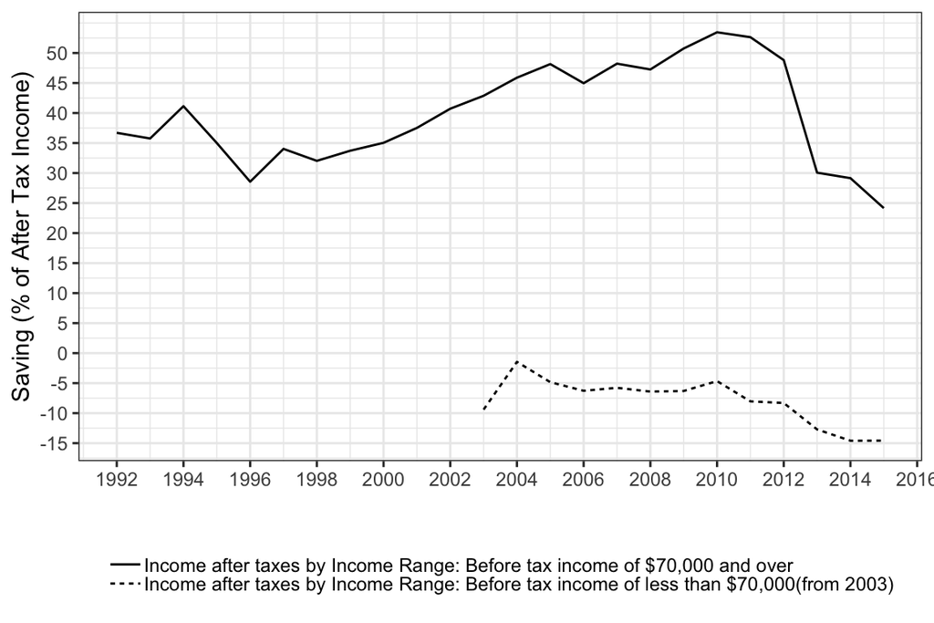